# Clasificador

Aplicación de reconocimiento de imágenes: compara cada fotograma de entrada con un conjunto de imágenes "modelo" guardadas en un directorio, usando uno de varios métodos de comparación intercambiables, y muestra el modelo más parecido junto con las distancias a todos los modelos.

## Cómo funciona

Cada fotograma se compara con un conjunto de imágenes "modelo" en un directorio, usando el método elegido. El más parecido se muestra junto con las distancias al resto.

Los descriptores de los modelos se precalculan al arrancar y se cachean en `.pkl` para no repetirlo en cada fotograma. Con `c` se puede capturar el frame actual como nuevo modelo desde la propia ventana.

## Métodos implementados

- **`embedding`**: vector de características de `mobilenet_v3_small` (mediapipe). Distancia: `1 - similitud coseno`. Bien para objetos/escenas completas.
- **`sift`**: puntos SIFT con el "ratio test" de Lowe. Distancia: `1 / nº de coincidencias`. Mejor para objetos con textura: carátulas, portadas...
- **`procrustes`**: 21 landmarks de mano (mediapipe), centrados y normalizados. Distancia: residuo de Procrustes ortogonal (SVD). Invariante a tamaño y orientación de la mano.

### Uso

```
./clasificador.py --models=modelos_embedding --method=embedding
./clasificador.py --models=modelos_sift      --method=sift
./clasificador.py --models=modelos_manos     --method=procrustes
```

`c` para añadir el frame actual como nuevo modelo. `--top` controla cuántos aparecen en el ranking (por defecto 5).

## Ejemplos

```python
import matplotlib.pyplot as plt
import cv2 as cv
import glob

def fig(w,h):
    plt.figure(figsize=(w,h))

def readrgb(file):
    return cv.cvtColor(cv.imread(file), cv.COLOR_BGR2RGB)

def show_examples(files, w=4, h=3.2):
    n = len(files)
    fig(w*n, h)
    for i,f in enumerate(sorted(files)):
        plt.subplot(1,n,i+1)
        plt.imshow(readrgb(f))
        plt.axis('off')
    plt.tight_layout()
    plt.show()
```

### `embedding`

Modelos guardados en `modelos_embedding/`: `gafas_sol`, `libreta`, `mando_consola`, `mouse_pc`, `posavasos`. En cada fotograma se muestra la similitud coseno con cada modelo; el más parecido aparece en la primera línea. Las gafas de sol, el posavasos, la libreta y el mando se reconocen correctamente como el modelo más similar.

[figure not shown]

```python
show_examples(glob.glob('ejemplos_embedding/*.png'))
```

### `procrustes` (gestos de mano)

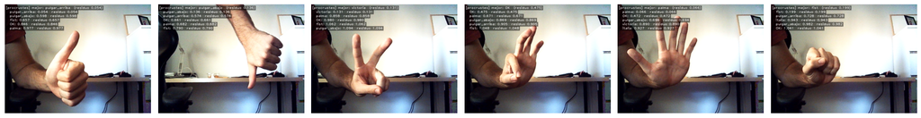

```python
show_examples(glob.glob('ejemplos_manos/*.png'), w=3.2, h=2.6)
```

### `sift` (carátulas)

Modelos guardados en `modelos_sift/`: portadas/carátulas de `berserk`, `darksouls3`, `eldenring`, `fallout4`, `harrypotter_camarasecreta`, `imperio_final`, `killing_joke` y `watchmen`. Se muestra el número de coincidencias SIFT (tras el "ratio test") con cada modelo; la carátula mostrada a la cámara se reconoce correctamente como la de mayor número de coincidencias, muy por encima del resto.

[figure not shown]

```python
show_examples(glob.glob('ejemplos_sift/*.png'), w=3.2, h=2.6)
```